# Risk Factor Analysis

## Outcome Variable

**Outcome Variable:** pers_wasted624

## Predictor Variables

**Intervention Variable:** ever_swasted06

**Adjustment Set:**

- sex
- arm
- enstunt
- month
- brthmon
- vagbrth
- single
- W_gagebrth
- W_birthwt
- W_birthlen
- W_mage
- W_mhtcm
- W_meducyrs
- W_feducyrs
- W_parity
- delta_month
- delta_brthmon
- delta_vagbrth
- delta_single
- delta_W_gagebrth
- delta_W_birthwt
- delta_W_birthlen
- delta_W_mage
- delta_W_mhtcm
- delta_W_meducyrs
- delta_W_feducyrs
- delta_W_parity

## Stratifying Variables

The analysis was stratified on these variable(s):

- studyid
- country

## Data Summary

| studyid | country | ever_swasted06 | pers_wasted624 | n_cell | n |
| --- | --- | --- | --- | --- | --- |
| ki0047075b-MAL-ED | BANGLADESH | 0 | 0 | 210 | 240 |
| ki0047075b-MAL-ED | BANGLADESH | 0 | 1 | 14 | 240 |
| ki0047075b-MAL-ED | BANGLADESH | 1 | 0 | 12 | 240 |
| ki0047075b-MAL-ED | BANGLADESH | 1 | 1 | 4 | 240 |
| ki0047075b-MAL-ED | BRAZIL | 0 | 0 | 203 | 207 |
| ki0047075b-MAL-ED | BRAZIL | 0 | 1 | 2 | 207 |
| ki0047075b-MAL-ED | BRAZIL | 1 | 0 | 2 | 207 |
| ki0047075b-MAL-ED | BRAZIL | 1 | 1 | 0 | 207 |
| ki0047075b-MAL-ED | INDIA | 0 | 0 | 198 | 235 |
| ki0047075b-MAL-ED | INDIA | 0 | 1 | 17 | 235 |
| ki0047075b-MAL-ED | INDIA | 1 | 0 | 9 | 235 |
| ki0047075b-MAL-ED | INDIA | 1 | 1 | 11 | 235 |
| ki0047075b-MAL-ED | NEPAL | 0 | 0 | 227 | 235 |
| ki0047075b-MAL-ED | NEPAL | 0 | 1 | 1 | 235 |
| ki0047075b-MAL-ED | NEPAL | 1 | 0 | 6 | 235 |
| ki0047075b-MAL-ED | NEPAL | 1 | 1 | 1 | 235 |
| ki0047075b-MAL-ED | PERU | 0 | 0 | 267 | 270 |
| ki0047075b-MAL-ED | PERU | 0 | 1 | 2 | 270 |
| ki0047075b-MAL-ED | PERU | 1 | 0 | 1 | 270 |
| ki0047075b-MAL-ED | PERU | 1 | 1 | 0 | 270 |
| ki0047075b-MAL-ED | SOUTH AFRICA | 0 | 0 | 252 | 259 |
| ki0047075b-MAL-ED | SOUTH AFRICA | 0 | 1 | 1 | 259 |
| ki0047075b-MAL-ED | SOUTH AFRICA | 1 | 0 | 5 | 259 |
| ki0047075b-MAL-ED | SOUTH AFRICA | 1 | 1 | 1 | 259 |
| ki0047075b-MAL-ED | TANZANIA, UNITED REPUBLIC OF | 0 | 0 | 241 | 245 |
| ki0047075b-MAL-ED | TANZANIA, UNITED REPUBLIC OF | 0 | 1 | 0 | 245 |
| ki0047075b-MAL-ED | TANZANIA, UNITED REPUBLIC OF | 1 | 0 | 4 | 245 |
| ki0047075b-MAL-ED | TANZANIA, UNITED REPUBLIC OF | 1 | 1 | 0 | 245 |
| ki1000108-CMC-V-BCS-2002 | INDIA | 0 | 0 | 284 | 370 |
| ki1000108-CMC-V-BCS-2002 | INDIA | 0 | 1 | 14 | 370 |

[output cut: 102 more lines]

The following strata were considered:

- studyid: ki0047075b-MAL-ED, country: BANGLADESH
- studyid: ki0047075b-MAL-ED, country: BRAZIL
- studyid: ki0047075b-MAL-ED, country: INDIA
- studyid: ki0047075b-MAL-ED, country: NEPAL
- studyid: ki0047075b-MAL-ED, country: PERU
- studyid: ki0047075b-MAL-ED, country: SOUTH AFRICA
- studyid: ki0047075b-MAL-ED, country: TANZANIA, UNITED REPUBLIC OF
- studyid: ki1000108-CMC-V-BCS-2002, country: INDIA
- studyid: ki1000108-IRC, country: INDIA
- studyid: ki1000109-EE, country: PAKISTAN
- studyid: ki1000109-ResPak, country: PAKISTAN
- studyid: ki1000304b-SAS-CompFeed, country: INDIA
- studyid: ki1000304b-SAS-FoodSuppl, country: INDIA
- studyid: ki1017093-NIH-Birth, country: BANGLADESH
- studyid: ki1017093b-PROVIDE, country: BANGLADESH
- studyid: ki1017093c-NIH-Crypto, country: BANGLADESH
- studyid: ki1066203-TanzaniaChild2, country: TANZANIA, UNITED REPUBLIC OF
- studyid: ki1101329-Keneba, country: GAMBIA
- studyid: ki1112895-Guatemala BSC, country: GUATEMALA
- studyid: ki1113344-GMS-Nepal, country: NEPAL
- studyid: ki1114097-CMIN, country: BANGLADESH
- studyid: ki1114097-CMIN, country: BRAZIL
- studyid: ki1114097-CMIN, country: GUINEA-BISSAU
- studyid: ki1114097-CMIN, country: PERU
- studyid: ki1114097-CONTENT, country: PERU
- studyid: ki1119695-PROBIT, country: BELARUS
- studyid: ki1126311-ZVITAMBO, country: ZIMBABWE
- studyid: ki1135781-COHORTS, country: GUATEMALA
- studyid: ki1135781-COHORTS, country: INDIA
- studyid: ki1135781-COHORTS, country: PHILIPPINES
- studyid: ki1148112-LCNI-5, country: MALAWI
- studyid: kiGH5241-JiVitA-3, country: BANGLADESH
- studyid: kiGH5241-JiVitA-4, country: BANGLADESH

### Dropped Strata

Some strata were dropped due to rare outcomes:

- studyid: ki0047075b-MAL-ED, country: BANGLADESH
- studyid: ki0047075b-MAL-ED, country: BRAZIL
- studyid: ki0047075b-MAL-ED, country: NEPAL
- studyid: ki0047075b-MAL-ED, country: PERU
- studyid: ki0047075b-MAL-ED, country: SOUTH AFRICA
- studyid: ki0047075b-MAL-ED, country: TANZANIA, UNITED REPUBLIC OF
- studyid: ki1112895-Guatemala BSC, country: GUATEMALA
- studyid: ki1114097-CMIN, country: BRAZIL
- studyid: ki1114097-CMIN, country: PERU
- studyid: ki1114097-CONTENT, country: PERU
- studyid: ki1135781-COHORTS, country: GUATEMALA
- studyid: ki1148112-LCNI-5, country: MALAWI

## Methods Detail

We’re interested in the causal parameters $E[Y_a]$ for all values of $a \in \mathcal{A}$. These parameters represent the mean outcome if, possibly contrary to fact, we intervened to set all units to have $A=a$. Under the randomization and positivity assumptions, these are identified by the statistical parameters $\psi_a=E_W[E_{Y|A,W}(Y|A=a,W)]$. In addition, we’re interested in the mean of $Y$, $E[Y]$ under no intervention (the observed mean). We will estimate these parameters by using SuperLearner to fit the relevant likelihood factors – $E_{Y|A,W}(Y|A=a,W)$ and $p(A=a|W)$, and then updating our likelihood fit using a joint TMLE.

For unadjusted analyses ($W=\{\}$), initial likelihoods were estimated using Lrnr_glm to estimate the simple $E(Y|A)$ and Lrnr_mean to estimate $p(A)$. For adjusted analyses, a small library containing Lrnr_glmnet, Lrnr_xgboost, and Lrnr_mean was used.

Having estimated these parameters, we will then use the delta method to estimate relative risks and attributable risks relative to a prespecified baseline level of $A$.

# Results Detail

## Results Plots

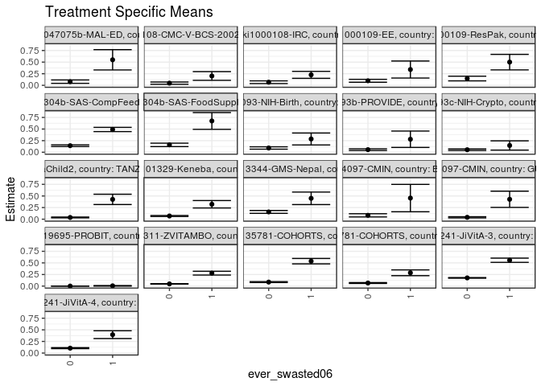

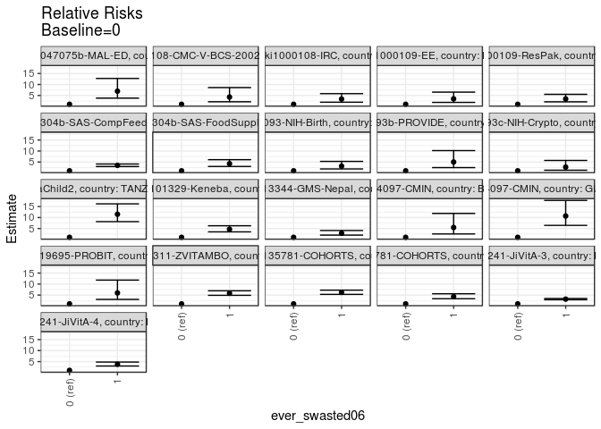

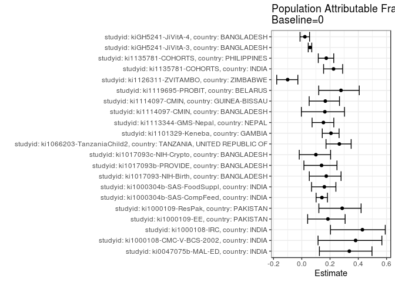

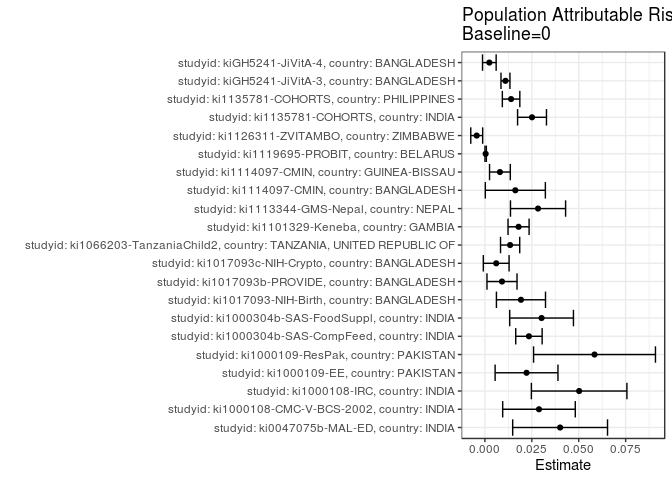

## Results Table

### Parameter: TSM

| studyid | country | intervention_level | baseline_level | estimate | ci_lower | ci_upper |
| --- | --- | --- | --- | --- | --- | --- |
| ki0047075b-MAL-ED | INDIA | 0 | NA | 0.0790698 | 0.0429227 | 0.1152169 |
| ki0047075b-MAL-ED | INDIA | 1 | NA | 0.5500000 | 0.3315024 | 0.7684976 |
| ki1000108-CMC-V-BCS-2002 | INDIA | 0 | NA | 0.0468546 | 0.0228324 | 0.0708768 |
| ki1000108-CMC-V-BCS-2002 | INDIA | 1 | NA | 0.2009956 | 0.1070467 | 0.2949446 |
| ki1000108-IRC | INDIA | 0 | NA | 0.0668488 | 0.0377004 | 0.0959973 |
| ki1000108-IRC | INDIA | 1 | NA | 0.2254769 | 0.1506146 | 0.3003391 |
| ki1000109-EE | PAKISTAN | 0 | NA | 0.0978123 | 0.0660958 | 0.1295288 |
| ki1000109-EE | PAKISTAN | 1 | NA | 0.3401720 | 0.1569876 | 0.5233563 |
| ki1000109-ResPak | PAKISTAN | 0 | NA | 0.1459287 | 0.0956429 | 0.1962144 |
| ki1000109-ResPak | PAKISTAN | 1 | NA | 0.4997698 | 0.3326949 | 0.6668447 |
| ki1000304b-SAS-CompFeed | INDIA | 0 | NA | 0.1412765 | 0.1228241 | 0.1597289 |
| ki1000304b-SAS-CompFeed | INDIA | 1 | NA | 0.4904141 | 0.4449694 | 0.5358588 |
| ki1000304b-SAS-FoodSuppl | INDIA | 0 | NA | 0.1588523 | 0.1218409 | 0.1958636 |
| ki1000304b-SAS-FoodSuppl | INDIA | 1 | NA | 0.6740336 | 0.4937165 | 0.8543507 |
| ki1017093-NIH-Birth | BANGLADESH | 0 | NA | 0.0916881 | 0.0660922 | 0.1172840 |
| ki1017093-NIH-Birth | BANGLADESH | 1 | NA | 0.2859942 | 0.1577414 | 0.4142469 |
| ki1017093b-PROVIDE | BANGLADESH | 0 | NA | 0.0559322 | 0.0373752 | 0.0744892 |
| ki1017093b-PROVIDE | BANGLADESH | 1 | NA | 0.2800000 | 0.1038524 | 0.4561476 |
| ki1017093c-NIH-Crypto | BANGLADESH | 0 | NA | 0.0542522 | 0.0372404 | 0.0712640 |
| ki1017093c-NIH-Crypto | BANGLADESH | 1 | NA | 0.1458333 | 0.0459197 | 0.2457470 |
| ki1066203-TanzaniaChild2 | TANZANIA, UNITED REPUBLIC OF | 0 | NA | 0.0371058 | 0.0287017 | 0.0455100 |
| ki1066203-TanzaniaChild2 | TANZANIA, UNITED REPUBLIC OF | 1 | NA | 0.4265984 | 0.3157834 | 0.5374134 |
| ki1101329-Keneba | GAMBIA | 0 | NA | 0.0688451 | 0.0581635 | 0.0795266 |
| ki1101329-Keneba | GAMBIA | 1 | NA | 0.3214260 | 0.2410652 | 0.4017868 |
| ki1113344-GMS-Nepal | NEPAL | 0 | NA | 0.1564267 | 0.1255815 | 0.1872719 |
| ki1113344-GMS-Nepal | NEPAL | 1 | NA | 0.4491688 | 0.3145595 | 0.5837781 |
| ki1114097-CMIN | BANGLADESH | 0 | NA | 0.0829876 | 0.0480898 | 0.1178853 |
| ki1114097-CMIN | BANGLADESH | 1 | NA | 0.4545455 | 0.1597077 | 0.7493832 |
| ki1114097-CMIN | GUINEA-BISSAU | 0 | NA | 0.0400802 | 0.0278501 | 0.0523103 |
| ki1114097-CMIN | GUINEA-BISSAU | 1 | NA | 0.4285714 | 0.2540096 | 0.6031333 |
| ki1119695-PROBIT | BELARUS | 0 | NA | 0.0010449 | 0.0002971 | 0.0017926 |
| ki1119695-PROBIT | BELARUS | 1 | NA | 0.0062354 | 0.0009301 | 0.0115407 |
| ki1126311-ZVITAMBO | ZIMBABWE | 0 | NA | 0.0479895 | 0.0434122 | 0.0525668 |
| ki1126311-ZVITAMBO | ZIMBABWE | 1 | NA | 0.2791088 | 0.2379901 | 0.3202276 |
| ki1135781-COHORTS | INDIA | 0 | NA | 0.0866111 | 0.0771067 | 0.0961156 |
| ki1135781-COHORTS | INDIA | 1 | NA | 0.5372130 | 0.4789991 | 0.5954270 |
| ki1135781-COHORTS | PHILIPPINES | 0 | NA | 0.0665314 | 0.0569532 | 0.0761097 |
| ki1135781-COHORTS | PHILIPPINES | 1 | NA | 0.2870048 | 0.2248703 | 0.3491393 |
| kiGH5241-JiVitA-3 | BANGLADESH | 0 | NA | 0.1770483 | 0.1705702 | 0.1835263 |
| kiGH5241-JiVitA-3 | BANGLADESH | 1 | NA | 0.5572521 | 0.5120442 | 0.6024600 |
| kiGH5241-JiVitA-4 | BANGLADESH | 0 | NA | 0.1049049 | 0.0941183 | 0.1156915 |
| kiGH5241-JiVitA-4 | BANGLADESH | 1 | NA | 0.3961226 | 0.3122118 | 0.4800333 |

### Parameter: E(Y)

| studyid | country | intervention_level | baseline_level | estimate | ci_lower | ci_upper |
| --- | --- | --- | --- | --- | --- | --- |
| ki0047075b-MAL-ED | INDIA | NA | NA | 0.1191489 | 0.0776405 | 0.1606574 |
| ki1000108-CMC-V-BCS-2002 | INDIA | NA | NA | 0.0756757 | 0.0486905 | 0.1026609 |
| ki1000108-IRC | INDIA | NA | NA | 0.1170732 | 0.0859146 | 0.1482317 |
| ki1000109-EE | PAKISTAN | NA | NA | 0.1200000 | 0.0870660 | 0.1529340 |
| ki1000109-ResPak | PAKISTAN | NA | NA | 0.2043478 | 0.1521230 | 0.2565727 |
| ki1000304b-SAS-CompFeed | INDIA | NA | NA | 0.1647399 | 0.1451050 | 0.1843747 |
| ki1000304b-SAS-FoodSuppl | INDIA | NA | NA | 0.1890547 | 0.1507312 | 0.2273783 |
| ki1017093-NIH-Birth | BANGLADESH | NA | NA | 0.1109057 | 0.0844206 | 0.1373909 |
| ki1017093b-PROVIDE | BANGLADESH | NA | NA | 0.0650407 | 0.0455353 | 0.0845460 |
| ki1017093c-NIH-Crypto | BANGLADESH | NA | NA | 0.0602740 | 0.0429977 | 0.0775502 |
| ki1066203-TanzaniaChild2 | TANZANIA, UNITED REPUBLIC OF | NA | NA | 0.0505451 | 0.0409848 | 0.0601054 |
| ki1101329-Keneba | GAMBIA | NA | NA | 0.0867841 | 0.0752007 | 0.0983676 |
| ki1113344-GMS-Nepal | NEPAL | NA | NA | 0.1847458 | 0.1534039 | 0.2160876 |
| ki1114097-CMIN | BANGLADESH | NA | NA | 0.0992063 | 0.0622241 | 0.1361886 |
| ki1114097-CMIN | GUINEA-BISSAU | NA | NA | 0.0480864 | 0.0349437 | 0.0612290 |
| ki1119695-PROBIT | BELARUS | NA | NA | 0.0014461 | 0.0004206 | 0.0024716 |
| ki1126311-ZVITAMBO | ZIMBABWE | NA | NA | 0.0436257 | 0.0397395 | 0.0475120 |
| ki1135781-COHORTS | INDIA | NA | NA | 0.1117237 | 0.1042858 | 0.1191617 |
| ki1135781-COHORTS | PHILIPPINES | NA | NA | 0.0804843 | 0.0704205 | 0.0905481 |
| kiGH5241-JiVitA-3 | BANGLADESH | NA | NA | 0.1880070 | 0.1814627 | 0.1945512 |
| kiGH5241-JiVitA-4 | BANGLADESH | NA | NA | 0.1072724 | 0.0967392 | 0.1178055 |

### Parameter: RR

| studyid | country | intervention_level | baseline_level | estimate | ci_lower | ci_upper |
| --- | --- | --- | --- | --- | --- | --- |
| ki0047075b-MAL-ED | INDIA | 0 | 0 | 1.000000 | 1.000000 | 1.000000 |
| ki0047075b-MAL-ED | INDIA | 1 | 0 | 6.955882 | 3.795960 | 12.746262 |
| ki1000108-CMC-V-BCS-2002 | INDIA | 0 | 0 | 1.000000 | 1.000000 | 1.000000 |
| ki1000108-CMC-V-BCS-2002 | INDIA | 1 | 0 | 4.289774 | 2.141724 | 8.592219 |
| ki1000108-IRC | INDIA | 0 | 0 | 1.000000 | 1.000000 | 1.000000 |
| ki1000108-IRC | INDIA | 1 | 0 | 3.372936 | 1.948063 | 5.840007 |
| ki1000109-EE | PAKISTAN | 0 | 0 | 1.000000 | 1.000000 | 1.000000 |
| ki1000109-EE | PAKISTAN | 1 | 0 | 3.477805 | 1.851179 | 6.533742 |
| ki1000109-ResPak | PAKISTAN | 0 | 0 | 1.000000 | 1.000000 | 1.000000 |
| ki1000109-ResPak | PAKISTAN | 1 | 0 | 3.424754 | 2.119546 | 5.533704 |
| ki1000304b-SAS-CompFeed | INDIA | 0 | 0 | 1.000000 | 1.000000 | 1.000000 |
| ki1000304b-SAS-CompFeed | INDIA | 1 | 0 | 3.471306 | 2.944999 | 4.091671 |
| ki1000304b-SAS-FoodSuppl | INDIA | 0 | 0 | 1.000000 | 1.000000 | 1.000000 |
| ki1000304b-SAS-FoodSuppl | INDIA | 1 | 0 | 4.243148 | 2.974388 | 6.053113 |
| ki1017093-NIH-Birth | BANGLADESH | 0 | 0 | 1.000000 | 1.000000 | 1.000000 |
| ki1017093-NIH-Birth | BANGLADESH | 1 | 0 | 3.119208 | 1.838779 | 5.291260 |
| ki1017093b-PROVIDE | BANGLADESH | 0 | 0 | 1.000000 | 1.000000 | 1.000000 |
| ki1017093b-PROVIDE | BANGLADESH | 1 | 0 | 5.006061 | 2.458188 | 10.194764 |
| ki1017093c-NIH-Crypto | BANGLADESH | 0 | 0 | 1.000000 | 1.000000 | 1.000000 |
| ki1017093c-NIH-Crypto | BANGLADESH | 1 | 0 | 2.688063 | 1.265352 | 5.710413 |
| ki1066203-TanzaniaChild2 | TANZANIA, UNITED REPUBLIC OF | 0 | 0 | 1.000000 | 1.000000 | 1.000000 |
| ki1066203-TanzaniaChild2 | TANZANIA, UNITED REPUBLIC OF | 1 | 0 | 11.496800 | 8.147515 | 16.222911 |
| ki1101329-Keneba | GAMBIA | 0 | 0 | 1.000000 | 1.000000 | 1.000000 |
| ki1101329-Keneba | GAMBIA | 1 | 0 | 4.668831 | 3.484452 | 6.255787 |
| ki1113344-GMS-Nepal | NEPAL | 0 | 0 | 1.000000 | 1.000000 | 1.000000 |
| ki1113344-GMS-Nepal | NEPAL | 1 | 0 | 2.871434 | 2.007031 | 4.108124 |
| ki1114097-CMIN | BANGLADESH | 0 | 0 | 1.000000 | 1.000000 | 1.000000 |
| ki1114097-CMIN | BANGLADESH | 1 | 0 | 5.477273 | 2.528380 | 11.865507 |
| ki1114097-CMIN | GUINEA-BISSAU | 0 | 0 | 1.000000 | 1.000000 | 1.000000 |
| ki1114097-CMIN | GUINEA-BISSAU | 1 | 0 | 10.692857 | 6.427866 | 17.787739 |
| ki1119695-PROBIT | BELARUS | 0 | 0 | 1.000000 | 1.000000 | 1.000000 |
| ki1119695-PROBIT | BELARUS | 1 | 0 | 5.967654 | 3.017791 | 11.800979 |
| ki1126311-ZVITAMBO | ZIMBABWE | 0 | 0 | 1.000000 | 1.000000 | 1.000000 |
| ki1126311-ZVITAMBO | ZIMBABWE | 1 | 0 | 5.816038 | 4.879112 | 6.932881 |
| ki1135781-COHORTS | INDIA | 0 | 0 | 1.000000 | 1.000000 | 1.000000 |
| ki1135781-COHORTS | INDIA | 1 | 0 | 6.202586 | 5.317389 | 7.235144 |
| ki1135781-COHORTS | PHILIPPINES | 0 | 0 | 1.000000 | 1.000000 | 1.000000 |
| ki1135781-COHORTS | PHILIPPINES | 1 | 0 | 4.313822 | 3.330286 | 5.587825 |
| kiGH5241-JiVitA-3 | BANGLADESH | 0 | 0 | 1.000000 | 1.000000 | 1.000000 |
| kiGH5241-JiVitA-3 | BANGLADESH | 1 | 0 | 3.147458 | 2.882864 | 3.436337 |
| kiGH5241-JiVitA-4 | BANGLADESH | 0 | 0 | 1.000000 | 1.000000 | 1.000000 |
| kiGH5241-JiVitA-4 | BANGLADESH | 1 | 0 | 3.776016 | 2.983972 | 4.778294 |

### Parameter: PAR

| studyid | country | intervention_level | baseline_level | estimate | ci_lower | ci_upper |
| --- | --- | --- | --- | --- | --- | --- |
| ki0047075b-MAL-ED | INDIA | 0 | NA | 0.0400792 | 0.0148059 | 0.0653525 |
| ki1000108-CMC-V-BCS-2002 | INDIA | 0 | NA | 0.0288211 | 0.0094749 | 0.0481673 |
| ki1000108-IRC | INDIA | 0 | NA | 0.0502243 | 0.0247678 | 0.0756809 |
| ki1000109-EE | PAKISTAN | 0 | NA | 0.0221877 | 0.0054420 | 0.0389334 |
| ki1000109-ResPak | PAKISTAN | 0 | NA | 0.0584192 | 0.0259423 | 0.0908961 |
| ki1000304b-SAS-CompFeed | INDIA | 0 | NA | 0.0234634 | 0.0164283 | 0.0304984 |
| ki1000304b-SAS-FoodSuppl | INDIA | 0 | NA | 0.0302025 | 0.0132166 | 0.0471884 |
| ki1017093-NIH-Birth | BANGLADESH | 0 | NA | 0.0192177 | 0.0061385 | 0.0322968 |
| ki1017093b-PROVIDE | BANGLADESH | 0 | NA | 0.0091084 | 0.0011028 | 0.0171141 |
| ki1017093c-NIH-Crypto | BANGLADESH | 0 | NA | 0.0060218 | -0.0008431 | 0.0128867 |
| ki1066203-TanzaniaChild2 | TANZANIA, UNITED REPUBLIC OF | 0 | NA | 0.0134393 | 0.0083260 | 0.0185526 |
| ki1101329-Keneba | GAMBIA | 0 | NA | 0.0179391 | 0.0123248 | 0.0235534 |
| ki1113344-GMS-Nepal | NEPAL | 0 | NA | 0.0283191 | 0.0136333 | 0.0430049 |
| ki1114097-CMIN | BANGLADESH | 0 | NA | 0.0162188 | 0.0002139 | 0.0322237 |
| ki1114097-CMIN | GUINEA-BISSAU | 0 | NA | 0.0080062 | 0.0024714 | 0.0135410 |
| ki1119695-PROBIT | BELARUS | 0 | NA | 0.0004013 | 0.0000329 | 0.0007697 |
| ki1126311-ZVITAMBO | ZIMBABWE | 0 | NA | -0.0043638 | -0.0075320 | -0.0011956 |
| ki1135781-COHORTS | INDIA | 0 | NA | 0.0251126 | 0.0174132 | 0.0328120 |
| ki1135781-COHORTS | PHILIPPINES | 0 | NA | 0.0139529 | 0.0092953 | 0.0186105 |
| kiGH5241-JiVitA-3 | BANGLADESH | 0 | NA | 0.0109587 | 0.0085717 | 0.0133456 |
| kiGH5241-JiVitA-4 | BANGLADESH | 0 | NA | 0.0023675 | -0.0012640 | 0.0059989 |

### Parameter: PAF

| studyid | country | intervention_level | baseline_level | estimate | ci_lower | ci_upper |
| --- | --- | --- | --- | --- | --- | --- |
| ki0047075b-MAL-ED | INDIA | 0 | NA | 0.3363787 | 0.1248069 | 0.4968046 |
| ki1000108-CMC-V-BCS-2002 | INDIA | 0 | NA | 0.3808500 | 0.1152117 | 0.5667362 |
| ki1000108-IRC | INDIA | 0 | NA | 0.4289995 | 0.2030589 | 0.5908837 |
| ki1000109-EE | PAKISTAN | 0 | NA | 0.1848978 | 0.0415492 | 0.3068067 |
| ki1000109-ResPak | PAKISTAN | 0 | NA | 0.2858811 | 0.1209677 | 0.4198553 |
| ki1000304b-SAS-CompFeed | INDIA | 0 | NA | 0.1424267 | 0.1012739 | 0.1816951 |
| ki1000304b-SAS-FoodSuppl | INDIA | 0 | NA | 0.1597552 | 0.0692408 | 0.2414673 |
| ki1017093-NIH-Birth | BANGLADESH | 0 | NA | 0.1732793 | 0.0532685 | 0.2780771 |
| ki1017093b-PROVIDE | BANGLADESH | 0 | NA | 0.1400424 | 0.0151570 | 0.2490913 |
| ki1017093c-NIH-Crypto | BANGLADESH | 0 | NA | 0.0999067 | -0.0178485 | 0.2040388 |
| ki1066203-TanzaniaChild2 | TANZANIA, UNITED REPUBLIC OF | 0 | NA | 0.2658865 | 0.1715237 | 0.3495015 |
| ki1101329-Keneba | GAMBIA | 0 | NA | 0.2067093 | 0.1450125 | 0.2639539 |
| ki1113344-GMS-Nepal | NEPAL | 0 | NA | 0.1532868 | 0.0729697 | 0.2266454 |
| ki1114097-CMIN | BANGLADESH | 0 | NA | 0.1634855 | -0.0027793 | 0.3021829 |
| ki1114097-CMIN | GUINEA-BISSAU | 0 | NA | 0.1664963 | 0.0523415 | 0.2669000 |
| ki1119695-PROBIT | BELARUS | 0 | NA | 0.2774767 | 0.1201276 | 0.4066867 |
| ki1126311-ZVITAMBO | ZIMBABWE | 0 | NA | -0.1000274 | -0.1772751 | -0.0278485 |
| ki1135781-COHORTS | INDIA | 0 | NA | 0.2247741 | 0.1544114 | 0.2892818 |
| ki1135781-COHORTS | PHILIPPINES | 0 | NA | 0.1733615 | 0.1168997 | 0.2262133 |
| kiGH5241-JiVitA-3 | BANGLADESH | 0 | NA | 0.0582886 | 0.0457768 | 0.0706364 |
| kiGH5241-JiVitA-4 | BANGLADESH | 0 | NA | 0.0220697 | -0.0122188 | 0.0551968 |